# **Name: BINAL DOSHI**

# **Sap Id: 53026250002**

# **OJT TOPIC : Global Stock Market Analytics-Predicting Market Direction**

# **Phase 1**

```python
import yfinance as yf
import pandas as pd
import numpy as np
from scipy.stats import shapiro
```

**Step 1 : Download NIFTY 50 data (India)**

```python
Nifty50 = yf.download("^NSEI", start="2016-01-01", end="2025-12-31")
```

```python
Nifty50.reset_index(inplace=True)
```

**Comment:** The index was reset to convert the date index into a regular column, which is required for merging datasets using the Date field.

```python
Nifty50.columns
```

```
MultiIndex([(  'Date',      ''),
            ( 'Close', '^NSEI'),
            (  'High', '^NSEI'),
            (   'Low', '^NSEI'),
            (  'Open', '^NSEI'),
            ('Volume', '^NSEI')],
           names=['Price', 'Ticker'])
```

```python
Nifty50.columns = Nifty50.columns.droplevel(1)
```

```python
Nifty50.columns
```

```
Index(['Date', 'Close', 'High', 'Low', 'Open', 'Volume'], dtype='object', name='Price')
```

```python
Nifty50.rename(columns={
    "Open": "Nifty50_Open",
    "High": "Nifty50_High",
    "Low": "Nifty50_Low",
    "Close": "Nifty50_Close",
    "Adj Close": "Nifty50_AdjClose",
    "Volume": "Nifty50_Volume"
}, inplace=True)
```

```python
Nifty50.head()
```

| Price | Date | Nifty50_Close | Nifty50_High | Nifty50_Low | Nifty50_Open | Nifty50_Volume |
| --- | --- | --- | --- | --- | --- | --- |
| 0 | 2016-01-04 | 7791.299805 | 7937.549805 | 7781.100098 | 7924.549805 | 134700 |
| 1 | 2016-01-05 | 7784.649902 | 7831.200195 | 7763.250000 | 7828.399902 | 145200 |
| 2 | 2016-01-06 | 7741.000000 | 7800.950195 | 7721.200195 | 7788.049805 | 147100 |
| 3 | 2016-01-07 | 7568.299805 | 7674.950195 | 7556.600098 | 7673.350098 | 188900 |
| 4 | 2016-01-08 | 7601.350098 | 7634.100098 | 7581.049805 | 7611.649902 | 157400 |

```python
Nifty50.shape
```

```
(2463, 6)
```

```python
Nifty50['Nifty50_Daily_Return'] = Nifty50['Nifty50_Close'].pct_change() * 100
```

**Comment:** Compares today’s price with yesterday’s price

Shows change in percentage

```python
Nifty50.tail()
```

| Price | Date | Nifty50_Close | Nifty50_High | Nifty50_Low | Nifty50_Open | Nifty50_Volume | Nifty50_Daily_Return |
| --- | --- | --- | --- | --- | --- | --- | --- |
| 2458 | 2025-12-23 | 26177.150391 | 26233.550781 | 26119.050781 | 26205.199219 | 216600 | 0.018149 |
| 2459 | 2025-12-24 | 26142.099609 | 26236.400391 | 26123.000000 | 26170.650391 | 188800 | -0.133898 |
| 2460 | 2025-12-26 | 26042.300781 | 26144.199219 | 26008.599609 | 26121.250000 | 142200 | -0.381755 |
| 2461 | 2025-12-29 | 25942.099609 | 26106.800781 | 25920.300781 | 26063.349609 | 234300 | -0.384763 |
| 2462 | 2025-12-30 | 25938.849609 | 25976.750000 | 25878.000000 | 25940.900391 | 396900 | -0.012528 |

```python
Nifty50.isnull().sum()
#No LOCF required as no null values found
```

| Price | 0 |
| --- | --- |
| Date | 0 |
| Nifty50_Close | 0 |
| Nifty50_High | 0 |
| Nifty50_Low | 0 |
| Nifty50_Open | 0 |
| Nifty50_Volume | 0 |
| Nifty50_Daily_Return | 1 |

**dtype:** int64

**Step 2: Download Dow Jones (USA)**

```python
DowJones = yf.download("^DJI", start="2016-01-01", end="2025-12-31")
```

```python
DowJones.reset_index(inplace=True)
```

```python
DowJones.columns
```

```
MultiIndex([(  'Date',     ''),
            ( 'Close', '^DJI'),
            (  'High', '^DJI'),
            (   'Low', '^DJI'),
            (  'Open', '^DJI'),
            ('Volume', '^DJI')],
           names=['Price', 'Ticker'])
```

```python
DowJones.columns = DowJones.columns.droplevel(1)
```

```python
DowJones.rename(columns={
    "Open": "DowJones_Open",
    "High": "DowJones_High",
    "Low": "DowJones_Low",
    "Close": "DowJones_Close",
    "Adj Close": "DowJones_AdjClose",
    "Volume": "DowJones_Volume"
}, inplace=True)
```

```python
DowJones['DowJones_Daily_Return'] = DowJones['DowJones_Close'].pct_change() * 100
```

```python
DowJones.tail()
```

| Price | Date | DowJones_Close | DowJones_High | DowJones_Low | DowJones_Open | DowJones_Volume | DowJones_Daily_Return |
| --- | --- | --- | --- | --- | --- | --- | --- |
| 2508 | 2025-12-23 | 48442.410156 | 48527.500000 | 48254.308594 | 48320.589844 | 418920000 | 0.164859 |
| 2509 | 2025-12-24 | 48731.160156 | 48771.320312 | 48386.589844 | 48424.710938 | 206740000 | 0.596069 |
| 2510 | 2025-12-26 | 48710.968750 | 48782.000000 | 48589.070312 | 48712.468750 | 288770000 | -0.041434 |
| 2511 | 2025-12-29 | 48461.929688 | 48704.828125 | 48390.910156 | 48636.628906 | 321850000 | -0.511259 |
| 2512 | 2025-12-30 | 48367.058594 | 48471.699219 | 48297.261719 | 48434.878906 | 282570000 | -0.195764 |

```python
DowJones.isnull().sum()
```

| Price | 0 |
| --- | --- |
| Date | 0 |
| DowJones_Close | 0 |
| DowJones_High | 0 |
| DowJones_Low | 0 |
| DowJones_Open | 0 |
| DowJones_Volume | 0 |
| DowJones_Daily_Return | 1 |

**dtype:** int64

**Step 3: Download NASDAQ Composite (USA)**

```python
NASDAQ = yf.download('^IXIC', start='2016-01-01', end='2025-12-31')
```

```python
NASDAQ.reset_index(inplace=True)
```

```python
NASDAQ.columns = NASDAQ.columns.droplevel(1)
```

```python
NASDAQ.rename(columns={
    "Open": "NASDAQ_Open",
    "High": "NASDAQ_High",
    "Low": "NASDAQ_Low",
    "Close": "NASDAQ_Close",
    "Adj Close": "NASDAQ_AdjClose",
    "Volume": "NASDAQ_Volume"
}, inplace=True)
```

```python
NASDAQ['NASDAQ_Daily_Return'] = NASDAQ['NASDAQ_Close'].pct_change() * 100
```

```python
NASDAQ.tail()
```

| Price | Date | NASDAQ_Close | NASDAQ_High | NASDAQ_Low | NASDAQ_Open | NASDAQ_Volume | NASDAQ_Daily_Return |
| --- | --- | --- | --- | --- | --- | --- | --- |
| 2508 | 2025-12-23 | 23561.839844 | 23563.460938 | 23377.490234 | 23407.699219 | 7518190000 | 0.567718 |
| 2509 | 2025-12-24 | 23613.310547 | 23621.720703 | 23527.970703 | 23555.949219 | 3885190000 | 0.218449 |
| 2510 | 2025-12-26 | 23593.099609 | 23665.150391 | 23567.859375 | 23645.910156 | 5170300000 | -0.085591 |
| 2511 | 2025-12-29 | 23474.349609 | 23531.019531 | 23397.519531 | 23414.679688 | 6527530000 | -0.503325 |
| 2512 | 2025-12-30 | 23419.080078 | 23521.050781 | 23414.830078 | 23465.669922 | 6769300000 | -0.235446 |

```python
NASDAQ.isnull().sum()
```

| Price | 0 |
| --- | --- |
| Date | 0 |
| NASDAQ_Close | 0 |
| NASDAQ_High | 0 |
| NASDAQ_Low | 0 |
| NASDAQ_Open | 0 |
| NASDAQ_Volume | 0 |
| NASDAQ_Daily_Return | 1 |

**dtype:** int64

**Step 4: Download Hang Seng Index (Hong Kong)**

```python
HangSeng = yf.download("^HSI", start="2016-01-01", end="2025-12-31")
```

```python
HangSeng.reset_index(inplace=True)
```

```python
HangSeng.columns = HangSeng.columns.droplevel(1)
```

```python
HangSeng.rename(columns={
    "Open": "HangSeng_Open",
    "High": "HangSeng_High",
    "Low": "HangSeng_Low",
    "Close": "HangSeng_Close",
    "Adj Close": "HangSeng_AdjClose",
    "Volume": "HangSeng_Volume"
}, inplace=True)
```

```python
HangSeng['HangSeng_Daily_Return'] = HangSeng['HangSeng_Close'].pct_change() * 100
```

```python
HangSeng.tail()
```

| Price | Date | HangSeng_Close | HangSeng_High | HangSeng_Low | HangSeng_Open | HangSeng_Volume | HangSeng_Daily_Return |
| --- | --- | --- | --- | --- | --- | --- | --- |
| 2453 | 2025-12-22 | 25801.769531 | 25859.609375 | 25671.330078 | 25795.939453 | 2362100000 | 0.433001 |
| 2454 | 2025-12-23 | 25774.140625 | 25927.660156 | 25726.449219 | 25875.849609 | 2240900000 | -0.107081 |
| 2455 | 2025-12-24 | 25818.929688 | 25890.869141 | 25772.869141 | 25780.089844 | 1236300000 | 0.173775 |
| 2456 | 2025-12-29 | 25635.230469 | 26082.939453 | 25630.750000 | 25928.890625 | 2931600000 | -0.711490 |
| 2457 | 2025-12-30 | 25854.599609 | 25930.220703 | 25611.230469 | 25636.400391 | 3138100000 | 0.855733 |

```python
HangSeng.isnull().sum()
```

| Price | 0 |
| --- | --- |
| Date | 0 |
| HangSeng_Close | 0 |
| HangSeng_High | 0 |
| HangSeng_Low | 0 |
| HangSeng_Open | 0 |
| HangSeng_Volume | 0 |
| HangSeng_Daily_Return | 1 |

**dtype:** int64

**Step 5: Download Nikkei 225 (Japan)**

```python
Nikkei225 = yf.download('^N225', start='2016-01-01', end='2025-12-31')
```

```python
Nikkei225.reset_index(inplace=True)
```

```python
Nikkei225.columns = Nikkei225.columns.droplevel(1)
```

```python
Nikkei225.rename(columns={
    "Open": "Nikkei225_Open",
    "High": "Nikkei225_High",
    "Low": "Nikkei225_Low",
    "Close": "Nikkei225_Close",
    "Adj Close": "Nikkei225_AdjClose",
    "Volume": "Nikkei225_Volume"
}, inplace=True)
```

```python
Nikkei225['Nikkei225_Daily_Return'] = Nikkei225['Nikkei225_Close'].pct_change() * 100
```

```python
Nikkei225.tail()
```

| Price | Date | Nikkei225_Close | Nikkei225_High | Nikkei225_Low | Nikkei225_Open | Nikkei225_Volume | Nikkei225_Daily_Return |
| --- | --- | --- | --- | --- | --- | --- | --- |
| 2439 | 2025-12-24 | 50344.101562 | 50636.949219 | 50323.921875 | 50475.480469 | 83200000 | -0.136413 |
| 2440 | 2025-12-25 | 50407.789062 | 50510.109375 | 50283.761719 | 50450.179688 | 58300000 | 0.126504 |
| 2441 | 2025-12-26 | 50750.390625 | 50941.890625 | 50527.128906 | 50527.128906 | 81100000 | 0.679660 |
| 2442 | 2025-12-29 | 50526.921875 | 50707.230469 | 50347.648438 | 50691.218750 | 98000000 | -0.440329 |
| 2443 | 2025-12-30 | 50339.480469 | 50534.640625 | 50198.968750 | 50312.851562 | 93700000 | -0.370973 |

```python
Nikkei225.isnull().sum()
```

| Price | 0 |
| --- | --- |
| Date | 0 |
| Nikkei225_Close | 0 |
| Nikkei225_High | 0 |
| Nikkei225_Low | 0 |
| Nikkei225_Open | 0 |
| Nikkei225_Volume | 0 |
| Nikkei225_Daily_Return | 1 |

**dtype:** int64

**Step 6: Download DAX Index (Germany)**

```python
DAX = yf.download('^GDAXI', start='2016-01-01', end='2025-12-31')
```

```python
DAX.reset_index(inplace=True)
```

```python
DAX.columns = DAX.columns.droplevel(1)
```

```python
DAX.rename(columns={
    "Open": "DAX_Open",
    "High": "DAX_High",
    "Low": "DAX_Low",
    "Close": "DAX_Close",
    "Adj Close": "DAX_AdjClose",
    "Volume": "DAX_Volume"
}, inplace=True)
```

```python
DAX['DAX_Daily_Return'] = DAX['DAX_Close'].pct_change() * 100
```

```python
DAX.tail()
```

| Price | Date | DAX_Close | DAX_High | DAX_Low | DAX_Open | DAX_Volume | DAX_Daily_Return |
| --- | --- | --- | --- | --- | --- | --- | --- |
| 2532 | 2025-12-19 | 24288.400391 | 24305.820312 | 24153.230469 | 24196.189453 | 131439800 | 0.367365 |
| 2533 | 2025-12-22 | 24283.970703 | 24356.109375 | 24203.369141 | 24291.849609 | 32252800 | -0.018238 |
| 2534 | 2025-12-23 | 24340.060547 | 24362.009766 | 24257.470703 | 24297.619141 | 28299400 | 0.230975 |
| 2535 | 2025-12-29 | 24351.119141 | 24389.150391 | 24253.730469 | 24370.939453 | 35372300 | 0.045434 |
| 2536 | 2025-12-30 | 24490.410156 | 24527.939453 | 24328.419922 | 24343.189453 | 23179300 | 0.572011 |

```python
DAX.isnull().sum()
```

| Price | 0 |
| --- | --- |
| Date | 0 |
| DAX_Close | 0 |
| DAX_High | 0 |
| DAX_Low | 0 |
| DAX_Open | 0 |
| DAX_Volume | 0 |
| DAX_Daily_Return | 1 |

**dtype:** int64

**Step 7: Download VIX Index**

```python
VIX = yf.download('^VIX', start='2016-01-01', end='2025-12-31')
```

```python
VIX.reset_index(inplace=True)
```

```python
VIX.columns = VIX.columns.droplevel(1)
```

```python
VIX.rename(columns={
    "Open": "VIX_Open",
    "High": "VIX_High",
    "Low": "VIX_Low",
    "Close": "VIX_Close",
    "Adj Close": "VIX_AdjClose",
    "Volume": "VIX_Volume"
}, inplace=True)
```

```python
VIX.tail()
```

| Price | Date | VIX_Close | VIX_High | VIX_Low | VIX_Open | VIX_Volume |
| --- | --- | --- | --- | --- | --- | --- |
| 2508 | 2025-12-23 | 14.00 | 14.45 | 13.64 | 14.09 | 0 |
| 2509 | 2025-12-24 | 13.47 | 14.16 | 13.38 | 14.09 | 0 |
| 2510 | 2025-12-26 | 13.60 | 14.29 | 13.52 | 14.12 | 0 |
| 2511 | 2025-12-29 | 14.20 | 15.08 | 13.99 | 14.69 | 0 |
| 2512 | 2025-12-30 | 14.33 | 14.62 | 14.04 | 14.43 | 0 |

```python
master_df = pd.merge(Nifty50, DowJones, on="Date", how="outer")
master_df = pd.merge(master_df, NASDAQ, on="Date", how="outer")
master_df = pd.merge(master_df, HangSeng, on="Date", how="outer")
master_df = pd.merge(master_df, Nikkei225, on="Date", how="outer")
master_df = pd.merge(master_df, DAX, on="Date", how="outer")

master_df.sort_values("Date", inplace=True)
master_df.reset_index(drop=True, inplace=True)

master_df.head()
```

| Price | Date | Nifty50_Close | Nifty50_High | Nifty50_Low | Nifty50_Open | Nifty50_Volume | Nifty50_Daily_Return | DowJones_Close | DowJones_High | DowJones_Low | ... | Nikkei225_Low | Nikkei225_Open | Nikkei225_Volume | Nikkei225_Daily_Return | DAX_Close | DAX_High | DAX_Low | DAX_Open | DAX_Volume | DAX_Daily_Return |
| --- | --- | --- | --- | --- | --- | --- | --- | --- | --- | --- | --- | --- | --- | --- | --- | --- | --- | --- | --- | --- | --- |
| 0 | 2016-01-04 | 7791.299805 | 7937.549805 | 7781.100098 | 7924.549805 | 134700.0 | NaN | 17148.939453 | 17405.480469 | 16957.630859 | ... | 18394.429688 | 18818.580078 | 140200000.0 | NaN | 10283.440430 | 10485.910156 | 10248.580078 | 10485.809570 | 119844300.0 | NaN |
| 1 | 2016-01-05 | 7784.649902 | 7831.200195 | 7763.250000 | 7828.399902 | 145200.0 | -0.085350 | 17158.660156 | 17195.839844 | 17038.609375 | ... | 18327.519531 | 18398.759766 | 132300000.0 | -0.417216 | 10310.099609 | 10384.259766 | 10173.519531 | 10373.269531 | 84894800.0 | 0.259244 |
| 2 | 2016-01-06 | 7741.000000 | 7800.950195 | 7721.200195 | 7788.049805 | 147100.0 | -0.560718 | 16906.509766 | 17154.830078 | 16817.619141 | ... | 18064.300781 | 18410.570312 | 142200000.0 | -0.994229 | 10214.019531 | 10288.679688 | 10094.179688 | 10288.679688 | 90465700.0 | -0.931903 |
| 3 | 2016-01-07 | 7568.299805 | 7674.950195 | 7556.600098 | 7673.350098 | 188900.0 | -2.230980 | 16514.099609 | 16888.359375 | 16463.630859 | ... | 17767.339844 | 18139.769531 | 168000000.0 | -2.330675 | 9979.849609 | 10145.469727 | 9810.469727 | 10144.169922 | 128029000.0 | -2.292632 |
| 4 | 2016-01-08 | 7601.350098 | 7634.100098 | 7581.049805 | 7611.649902 | 157400.0 | 0.436694 | 16346.450195 | 16651.890625 | 16314.570312 | ... | 17509.640625 | 17562.230469 | 184300000.0 | -0.390486 | 9849.339844 | 10122.459961 | 9849.339844 | 10010.469727 | 98631100.0 | -1.307733 |

5 rows × 37 columns

```python
master_df.isnull().sum()
```

| Price | 0 |
| --- | --- |
| Date | 0 |
| Nifty50_Close | 143 |
| Nifty50_High | 143 |
| Nifty50_Low | 143 |
| Nifty50_Open | 143 |
| Nifty50_Volume | 143 |
| Nifty50_Daily_Return | 144 |
| DowJones_Close | 93 |
| DowJones_High | 93 |
| DowJones_Low | 93 |
| DowJones_Open | 93 |
| DowJones_Volume | 93 |
| DowJones_Daily_Return | 94 |
| NASDAQ_Close | 93 |
| NASDAQ_High | 93 |
| NASDAQ_Low | 93 |
| NASDAQ_Open | 93 |
| NASDAQ_Volume | 93 |
| NASDAQ_Daily_Return | 94 |
| HangSeng_Close | 148 |
| HangSeng_High | 148 |
| HangSeng_Low | 148 |
| HangSeng_Open | 148 |
| HangSeng_Volume | 148 |
| HangSeng_Daily_Return | 149 |
| Nikkei225_Close | 162 |
| Nikkei225_High | 162 |
| Nikkei225_Low | 162 |
| Nikkei225_Open | 162 |
| Nikkei225_Volume | 162 |
| Nikkei225_Daily_Return | 163 |
| DAX_Close | 69 |
| DAX_High | 69 |
| DAX_Low | 69 |
| DAX_Open | 69 |
| DAX_Volume | 69 |
| DAX_Daily_Return | 70 |

**dtype:** int64

**Apply LOCF Imputation**

```python
master_df.fillna(method='ffill', inplace=True)
```

```python
master_df.isnull().sum()
```

| Price | 0 |
| --- | --- |
| Date | 0 |
| Nifty50_Close | 0 |
| Nifty50_High | 0 |
| Nifty50_Low | 0 |
| Nifty50_Open | 0 |
| Nifty50_Volume | 0 |
| Nifty50_Daily_Return | 1 |
| DowJones_Close | 0 |
| DowJones_High | 0 |
| DowJones_Low | 0 |
| DowJones_Open | 0 |
| DowJones_Volume | 0 |
| DowJones_Daily_Return | 1 |
| NASDAQ_Close | 0 |
| NASDAQ_High | 0 |
| NASDAQ_Low | 0 |
| NASDAQ_Open | 0 |
| NASDAQ_Volume | 0 |
| NASDAQ_Daily_Return | 1 |
| HangSeng_Close | 0 |
| HangSeng_High | 0 |
| HangSeng_Low | 0 |
| HangSeng_Open | 0 |
| HangSeng_Volume | 0 |
| HangSeng_Daily_Return | 1 |
| Nikkei225_Close | 0 |
| Nikkei225_High | 0 |
| Nikkei225_Low | 0 |
| Nikkei225_Open | 0 |
| Nikkei225_Volume | 0 |
| Nikkei225_Daily_Return | 1 |
| DAX_Close | 0 |
| DAX_High | 0 |
| DAX_Low | 0 |
| DAX_Open | 0 |
| DAX_Volume | 0 |
| DAX_Daily_Return | 1 |

**dtype:** int64

**Create Quarter Indicator**

```python
master_df['Quarter'] = master_df['Date'].dt.quarter
```

**Create Month Indicator**

```python
master_df['Month'] = master_df['Date'].dt.month
```

**Create Year Indicator**

```python
master_df['Year'] = master_df['Date'].dt.year
```

```python
master_df.head()
```

| Price | Date | Nifty50_Close | Nifty50_High | Nifty50_Low | Nifty50_Open | Nifty50_Volume | Nifty50_Daily_Return | DowJones_Close | DowJones_High | DowJones_Low | ... | Nikkei225_Daily_Return | DAX_Close | DAX_High | DAX_Low | DAX_Open | DAX_Volume | DAX_Daily_Return | Quarter | Month | Year |
| --- | --- | --- | --- | --- | --- | --- | --- | --- | --- | --- | --- | --- | --- | --- | --- | --- | --- | --- | --- | --- | --- |
| 0 | 2016-01-04 | 7791.299805 | 7937.549805 | 7781.100098 | 7924.549805 | 134700.0 | NaN | 17148.939453 | 17405.480469 | 16957.630859 | ... | NaN | 10283.440430 | 10485.910156 | 10248.580078 | 10485.809570 | 119844300.0 | NaN | 1 | 1 | 2016 |
| 1 | 2016-01-05 | 7784.649902 | 7831.200195 | 7763.250000 | 7828.399902 | 145200.0 | -0.085350 | 17158.660156 | 17195.839844 | 17038.609375 | ... | -0.417216 | 10310.099609 | 10384.259766 | 10173.519531 | 10373.269531 | 84894800.0 | 0.259244 | 1 | 1 | 2016 |
| 2 | 2016-01-06 | 7741.000000 | 7800.950195 | 7721.200195 | 7788.049805 | 147100.0 | -0.560718 | 16906.509766 | 17154.830078 | 16817.619141 | ... | -0.994229 | 10214.019531 | 10288.679688 | 10094.179688 | 10288.679688 | 90465700.0 | -0.931903 | 1 | 1 | 2016 |
| 3 | 2016-01-07 | 7568.299805 | 7674.950195 | 7556.600098 | 7673.350098 | 188900.0 | -2.230980 | 16514.099609 | 16888.359375 | 16463.630859 | ... | -2.330675 | 9979.849609 | 10145.469727 | 9810.469727 | 10144.169922 | 128029000.0 | -2.292632 | 1 | 1 | 2016 |
| 4 | 2016-01-08 | 7601.350098 | 7634.100098 | 7581.049805 | 7611.649902 | 157400.0 | 0.436694 | 16346.450195 | 16651.890625 | 16314.570312 | ... | -0.390486 | 9849.339844 | 10122.459961 | 9849.339844 | 10010.469727 | 98631100.0 | -1.307733 | 1 | 1 | 2016 |

5 rows × 40 columns

```python
master_df.tail()
```

| Price | Date | Nifty50_Close | Nifty50_High | Nifty50_Low | Nifty50_Open | Nifty50_Volume | Nifty50_Daily_Return | DowJones_Close | DowJones_High | DowJones_Low | ... | Nikkei225_Daily_Return | DAX_Close | DAX_High | DAX_Low | DAX_Open | DAX_Volume | DAX_Daily_Return | Quarter | Month | Year |
| --- | --- | --- | --- | --- | --- | --- | --- | --- | --- | --- | --- | --- | --- | --- | --- | --- | --- | --- | --- | --- | --- |
| 2601 | 2025-12-24 | 26142.099609 | 26236.400391 | 26123.000000 | 26170.650391 | 188800.0 | -0.133898 | 48731.160156 | 48771.320312 | 48386.589844 | ... | -0.136413 | 24340.060547 | 24362.009766 | 24257.470703 | 24297.619141 | 28299400.0 | 0.230975 | 4 | 12 | 2025 |
| 2602 | 2025-12-25 | 26142.099609 | 26236.400391 | 26123.000000 | 26170.650391 | 188800.0 | -0.133898 | 48731.160156 | 48771.320312 | 48386.589844 | ... | 0.126504 | 24340.060547 | 24362.009766 | 24257.470703 | 24297.619141 | 28299400.0 | 0.230975 | 4 | 12 | 2025 |
| 2603 | 2025-12-26 | 26042.300781 | 26144.199219 | 26008.599609 | 26121.250000 | 142200.0 | -0.381755 | 48710.968750 | 48782.000000 | 48589.070312 | ... | 0.679660 | 24340.060547 | 24362.009766 | 24257.470703 | 24297.619141 | 28299400.0 | 0.230975 | 4 | 12 | 2025 |
| 2604 | 2025-12-29 | 25942.099609 | 26106.800781 | 25920.300781 | 26063.349609 | 234300.0 | -0.384763 | 48461.929688 | 48704.828125 | 48390.910156 | ... | -0.440329 | 24351.119141 | 24389.150391 | 24253.730469 | 24370.939453 | 35372300.0 | 0.045434 | 4 | 12 | 2025 |
| 2605 | 2025-12-30 | 25938.849609 | 25976.750000 | 25878.000000 | 25940.900391 | 396900.0 | -0.012528 | 48367.058594 | 48471.699219 | 48297.261719 | ... | -0.370973 | 24490.410156 | 24527.939453 | 24328.419922 | 24343.189453 | 23179300.0 | 0.572011 | 4 | 12 | 2025 |

5 rows × 40 columns

```python
master_df.shape
```

```
(2606, 40)
```

**Check Normal Distribution**

**Comment:** We want to see whether daily returns behave like a normal (bell-shaped) distribution or not.

```python
from scipy.stats import shapiro

columns = [
    'Nifty50_Daily_Return',
    'DowJones_Daily_Return',
    'NASDAQ_Daily_Return',
    'HangSeng_Daily_Return',
    'Nikkei225_Daily_Return',
    'DAX_Daily_Return'
]

for col in columns:
    stat, p = shapiro(master_df[col].dropna())
    print(col, "p-value:", p)
```

```
Nifty50_Daily_Return p-value: 8.94099024021726e-41
DowJones_Daily_Return p-value: 1.4969030780714503e-45
NASDAQ_Daily_Return p-value: 2.2612004530098785e-35
HangSeng_Daily_Return p-value: 1.559156015254688e-27
Nikkei225_Daily_Return p-value: 1.8456149294764425e-34
DAX_Daily_Return p-value: 2.7402479383810763e-36
```

**Daily returns do NOT follow a normal distribution** 📌 Decision Rule (Remember This)

p-value ≤ 0.05 → ❌ Not Normal

p-value > 0.05 → ✔ Normal

Since all p-values ≪ 0.05, we reject the normality assumption.

# **Phase 2**

```python
master_df.to_csv("Phase1_Master_Data.csv", index=False)
```

```python
import pandas as pd
import numpy as np
import matplotlib.pyplot as plt
import seaborn as sns
from statsmodels.stats.outliers_influence import variance_inflation_factor
```

**Import the Data**

```python
master_df = pd.read_csv("Phase1_Master_Data.csv")
master_df["Date"] = pd.to_datetime(master_df["Date"])
master_df.head()
```

|  | Date | Nifty50_Close | Nifty50_High | Nifty50_Low | Nifty50_Open | Nifty50_Volume | Nifty50_Daily_Return | DowJones_Close | DowJones_High | DowJones_Low | ... | Nikkei225_Daily_Return | DAX_Close | DAX_High | DAX_Low | DAX_Open | DAX_Volume | DAX_Daily_Return | Quarter | Month | Year |
| --- | --- | --- | --- | --- | --- | --- | --- | --- | --- | --- | --- | --- | --- | --- | --- | --- | --- | --- | --- | --- | --- |
| 0 | 2016-01-04 | 7791.299805 | 7937.549805 | 7781.100098 | 7924.549805 | 134700.0 | NaN | 17148.939453 | 17405.480469 | 16957.630859 | ... | NaN | 10283.440430 | 10485.910156 | 10248.580078 | 10485.809570 | 119844300.0 | NaN | 1 | 1 | 2016 |
| 1 | 2016-01-05 | 7784.649902 | 7831.200195 | 7763.250000 | 7828.399902 | 145200.0 | -0.085350 | 17158.660156 | 17195.839844 | 17038.609375 | ... | -0.417216 | 10310.099609 | 10384.259766 | 10173.519531 | 10373.269531 | 84894800.0 | 0.259244 | 1 | 1 | 2016 |
| 2 | 2016-01-06 | 7741.000000 | 7800.950195 | 7721.200195 | 7788.049805 | 147100.0 | -0.560718 | 16906.509766 | 17154.830078 | 16817.619141 | ... | -0.994229 | 10214.019531 | 10288.679688 | 10094.179688 | 10288.679688 | 90465700.0 | -0.931903 | 1 | 1 | 2016 |
| 3 | 2016-01-07 | 7568.299805 | 7674.950195 | 7556.600098 | 7673.350098 | 188900.0 | -2.230980 | 16514.099609 | 16888.359375 | 16463.630859 | ... | -2.330675 | 9979.849609 | 10145.469727 | 9810.469727 | 10144.169922 | 128029000.0 | -2.292632 | 1 | 1 | 2016 |
| 4 | 2016-01-08 | 7601.350098 | 7634.100098 | 7581.049805 | 7611.649902 | 157400.0 | 0.436694 | 16346.450195 | 16651.890625 | 16314.570312 | ... | -0.390486 | 9849.339844 | 10122.459961 | 9849.339844 | 10010.469727 | 98631100.0 | -1.307733 | 1 | 1 | 2016 |

5 rows × 40 columns

Check Missing Values

```python
master_df.isnull().sum()    #Only first-day return values are missing, which is expected in return calculations.
```

|  | 0 |
| --- | --- |
| Date | 0 |
| Nifty50_Close | 0 |
| Nifty50_High | 0 |
| Nifty50_Low | 0 |
| Nifty50_Open | 0 |
| Nifty50_Volume | 0 |
| Nifty50_Daily_Return | 1 |
| DowJones_Close | 0 |
| DowJones_High | 0 |
| DowJones_Low | 0 |
| DowJones_Open | 0 |
| DowJones_Volume | 0 |
| DowJones_Daily_Return | 1 |
| NASDAQ_Close | 0 |
| NASDAQ_High | 0 |
| NASDAQ_Low | 0 |
| NASDAQ_Open | 0 |
| NASDAQ_Volume | 0 |
| NASDAQ_Daily_Return | 1 |
| HangSeng_Close | 0 |
| HangSeng_High | 0 |
| HangSeng_Low | 0 |
| HangSeng_Open | 0 |
| HangSeng_Volume | 0 |
| HangSeng_Daily_Return | 1 |
| Nikkei225_Close | 0 |
| Nikkei225_High | 0 |
| Nikkei225_Low | 0 |
| Nikkei225_Open | 0 |
| Nikkei225_Volume | 0 |
| Nikkei225_Daily_Return | 1 |
| DAX_Close | 0 |
| DAX_High | 0 |
| DAX_Low | 0 |
| DAX_Open | 0 |
| DAX_Volume | 0 |
| DAX_Daily_Return | 1 |
| Quarter | 0 |
| Month | 0 |
| Year | 0 |

**dtype:** int64

# **1) Global Indices 10 years Performance Analytics:(For each index (a to f above)**

**Use last 10 years data (Example: 2016-2025)**

**Create 10-year dataset**

```python
df_5y = master_df[
    (master_df['Date'] >= '2016-01-04') &
    (master_df['Date'] <= '2025-12-31')
].copy()


df_5y['Year'] = df_5y['Date'].dt.year
df_5y['Quarter'] = df_5y['Date'].dt.quarter
```

**1(a) Box-Whisker Plot of daily returns by YEAR**

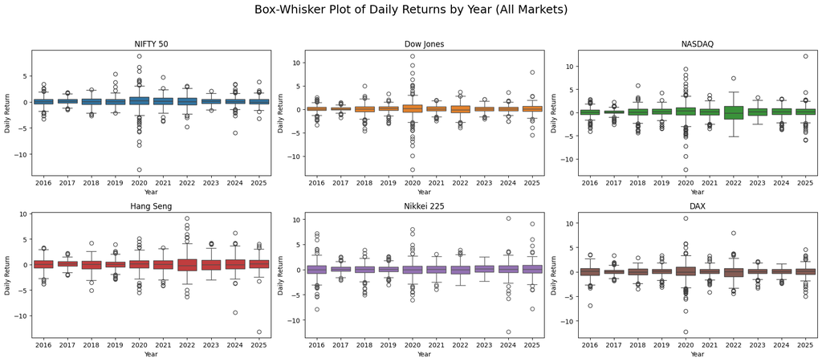

```python
import matplotlib.pyplot as plt
import seaborn as sns

markets = [
    ('Nifty50_Daily_Return', 'NIFTY 50', '#1f77b4'),
    ('DowJones_Daily_Return', 'Dow Jones', '#ff7f0e'),
    ('NASDAQ_Daily_Return', 'NASDAQ', '#2ca02c'),
    ('HangSeng_Daily_Return', 'Hang Seng', '#d62728'),
    ('Nikkei225_Daily_Return', 'Nikkei 225', '#9467bd'),
    ('DAX_Daily_Return', 'DAX', '#8c564b')
]

fig, axes = plt.subplots(2, 3, figsize=(18, 8))
axes = axes.flatten()

for ax, (col, title, color) in zip(axes, markets):
    sns.boxplot(
        x='Year',
        y=col,
        data=df_5y,
        ax=ax,
        color=color
    )
    ax.set_title(title)
    ax.set_xlabel('Year')
    ax.set_ylabel('Daily Return')

plt.suptitle(
    "Box-Whisker Plot of Daily Returns by Year (All Markets)",
    fontsize=18
)

plt.tight_layout(rect=[0, 0, 1, 0.95])
plt.show()
```

**Comment:** Box-Whisker Plot of Daily Returns (2016–2025)

NIFTY 50 shows relatively moderate volatility compared to global indices, with returns mostly clustered around zero except during 2020.

Dow Jones and NASDAQ exhibit larger positive and negative outliers, especially NASDAQ, indicating higher risk–return behavior in the US markets.

NASDAQ displays strong recovery after 2020, with wider upper whiskers in later years, reflecting higher positive returns.

Hang Seng shows persistent volatility and weaker performance, with frequent negative outliers even in post-COVID years, indicating prolonged market stress.

Nikkei 225 has stable returns in most years, but with occasional sharp negative outliers, especially around global crisis periods.

DAX demonstrates moderate volatility, with noticeable downside risk during 2020 and gradual stabilization in subsequent years.

**1(b) Table of daily returns by YEAR (n, mean, std)**

**Nifty50**

```python
df_5y.groupby('Year')['Nifty50_Daily_Return'].agg(
    Count='count',
    Mean='mean',
    Std_Dev='std'
)
```

| Year | Count | Mean | Std_Dev |
| --- | --- | --- | --- |
| 2016 | 259 | 0.028504 | 0.958040 |
| 2017 | 260 | 0.105588 | 0.571721 |
| 2018 | 260 | 0.011858 | 0.804320 |
| 2019 | 260 | 0.061655 | 0.862269 |
| 2020 | 262 | 0.059276 | 2.003775 |
| 2021 | 261 | 0.093951 | 0.979932 |
| 2022 | 260 | 0.054513 | 1.096428 |
| 2023 | 260 | 0.079254 | 0.620049 |
| 2024 | 262 | 0.043982 | 0.863900 |
| 2025 | 261 | 0.044510 | 0.750359 |

**Comment:** • Count → Number of trading days in that year

• Mean → Average daily return (overall performance)

• Std_Dev → Volatility or risk (how much returns fluctuate)

**DowJones**

```python
df_5y.groupby('Year')['DowJones_Daily_Return'].agg(
    Count='count',
    Mean='mean',
    Std_Dev='std'
)
```

| Year | Count | Mean | Std_Dev |
| --- | --- | --- | --- |
| 2016 | 259 | 0.061008 | 0.801154 |
| 2017 | 260 | 0.084714 | 0.415707 |
| 2018 | 260 | -0.034755 | 1.142622 |
| 2019 | 260 | 0.098867 | 0.783563 |
| 2020 | 262 | 0.056509 | 2.277254 |
| 2021 | 261 | 0.074976 | 0.772875 |
| 2022 | 260 | -0.024515 | 1.237294 |
| 2023 | 260 | 0.059685 | 0.708875 |
| 2024 | 262 | 0.051103 | 0.706425 |
| 2025 | 261 | 0.052960 | 1.036729 |

**NASDAQ**

```python
df_5y.groupby('Year')['NASDAQ_Daily_Return'].agg(
    Count='count',
    Mean='mean',
    Std_Dev='std'
)
```

| Year | Count | Mean | Std_Dev |
| --- | --- | --- | --- |
| 2016 | 259 | 0.043482 | 1.001173 |
| 2017 | 260 | 0.094157 | 0.600251 |
| 2018 | 260 | -0.020231 | 1.329736 |
| 2019 | 260 | 0.132933 | 0.974714 |
| 2020 | 262 | 0.170412 | 2.199609 |
| 2021 | 261 | 0.095541 | 1.123517 |
| 2022 | 260 | -0.124394 | 2.000332 |
| 2023 | 260 | 0.156594 | 1.084932 |
| 2024 | 262 | 0.111630 | 1.127109 |
| 2025 | 261 | 0.087320 | 1.511013 |

**HangSeng**

```python
df_5y.groupby('Year')['HangSeng_Daily_Return'].agg(
    Count='count',
    Mean='mean',
    Std_Dev='std'
)
```

| Year | Count | Mean | Std_Dev |
| --- | --- | --- | --- |
| 2016 | 259 | 0.013996 | 1.167424 |
| 2017 | 260 | 0.139309 | 0.700700 |
| 2018 | 260 | -0.034949 | 1.243767 |
| 2019 | 260 | 0.033120 | 0.980864 |
| 2020 | 262 | 0.026129 | 1.444816 |
| 2021 | 261 | -0.028481 | 1.262121 |
| 2022 | 260 | -0.020744 | 2.054467 |
| 2023 | 260 | -0.052676 | 1.408653 |
| 2024 | 262 | 0.101216 | 1.572058 |
| 2025 | 261 | 0.123351 | 1.486340 |

**Nikkei225**

```python
df_5y.groupby('Year')['Nikkei225_Daily_Return'].agg(
    Count='count',
    Mean='mean',
    Std_Dev='std'
)
```

| Year | Count | Mean | Std_Dev |
| --- | --- | --- | --- |
| 2016 | 259 | -0.032790 | 1.717807 |
| 2017 | 260 | 0.081290 | 0.736451 |
| 2018 | 260 | -0.047420 | 1.198187 |
| 2019 | 260 | 0.065377 | 0.860102 |
| 2020 | 262 | 0.013181 | 1.614888 |
| 2021 | 261 | 0.028503 | 1.152231 |
| 2022 | 260 | -0.036233 | 1.261568 |
| 2023 | 260 | 0.105084 | 0.998616 |
| 2024 | 262 | 0.076366 | 1.616104 |
| 2025 | 261 | 0.103274 | 1.483575 |

**DAX**

```python
df_5y.groupby('Year')['DAX_Daily_Return'].agg(
    Count='count',
    Mean='mean',
    Std_Dev='std'
)
```

| Year | Count | Mean | Std_Dev |
| --- | --- | --- | --- |
| 2016 | 259 | 0.044713 | 1.286104 |
| 2017 | 260 | 0.049631 | 0.665195 |
| 2018 | 260 | -0.055542 | 0.975185 |
| 2019 | 260 | 0.084212 | 0.887599 |
| 2020 | 262 | 0.042611 | 2.063860 |
| 2021 | 261 | 0.070506 | 0.898895 |
| 2022 | 260 | -0.034584 | 1.460441 |
| 2023 | 260 | 0.082085 | 0.809460 |
| 2024 | 262 | 0.063062 | 0.750623 |
| 2025 | 261 | 0.084130 | 1.099415 |

**1(c) Bar Plot of median daily return by YEAR**

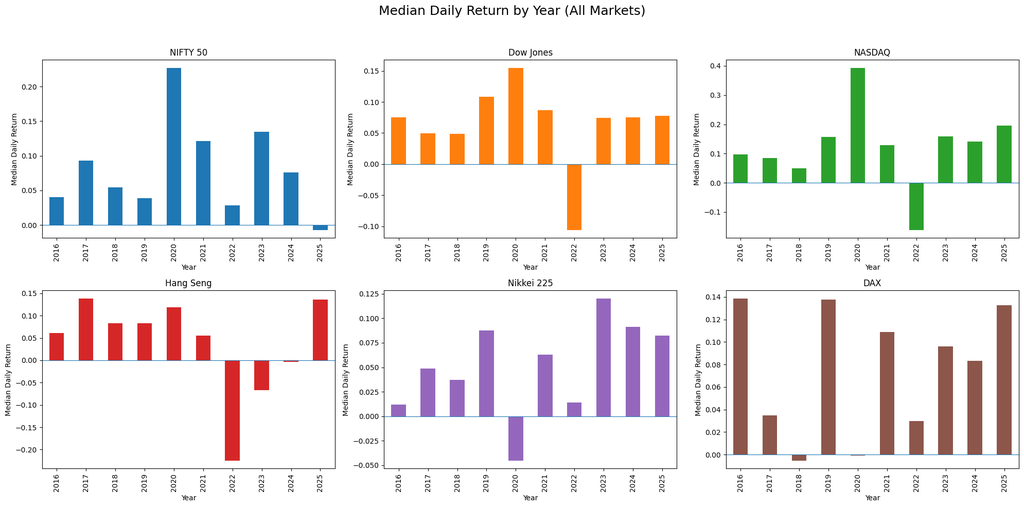

```python
# Create 2x3 subplot layout
fig, axes = plt.subplots(2, 3, figsize=(20, 10))
fig.suptitle("Median Daily Return by Year (All Markets)", fontsize=18)

markets = [
    ("Nifty50_Daily_Return", "NIFTY 50", "#1f77b4"),     # Blue
    ("DowJones_Daily_Return", "Dow Jones", "#ff7f0e"),   # Orange
    ("NASDAQ_Daily_Return", "NASDAQ", "#2ca02c"),       # Green
    ("HangSeng_Daily_Return", "Hang Seng", "#d62728"),  # Red
    ("Nikkei225_Daily_Return", "Nikkei 225", "#9467bd"),# Purple
    ("DAX_Daily_Return", "DAX", "#8c564b")              # Brown
]

# Define different colors
colors = ["blue", "seagreen", "crimson", "teal""darkorange", "purple",]


# Loop through markets
for ax, (col, title, color) in zip(axes.flatten(), markets):
    median_returns = df_5y.groupby("Year")[col].median()

    median_returns.plot(
        kind="bar",
        ax=ax,
        color=color
    )

    ax.set_title(title)
    ax.set_xlabel("Year")
    ax.set_ylabel("Median Daily Return")
    ax.axhline(0, linewidth=0.8)  # zero reference line

plt.tight_layout(rect=[0, 0, 1, 0.95])
plt.show()
```

**Comments – Median Daily Return by Year (2016–2025)**

NIFTY 50 shows a strong positive median in 2020, indicating a fast recovery after the initial COVID shock, while 2025 shows near-zero to slightly negative median, suggesting recent market consolidation.

Dow Jones performs well in most years, but 2022 shows a clear negative median return, reflecting the impact of inflation concerns and aggressive interest-rate hikes.

NASDAQ records the highest positive median in 2020, highlighting strong gains in technology stocks during the pandemic, followed by a sharp negative median in 2022, indicating tech-sector correction.

Nikkei 225 shows mixed but generally positive performance, with a small dip around 2020 and strong recovery in later years.

DAX maintains mostly positive median returns, indicating relative stability of the European market, with minor slowdowns during global uncertainty.

Overall, US markets show higher return potential but higher volatility, while Asian markets exhibit uneven recovery, and NIFTY remains comparatively resilient.

**1(d) Heat Map by YEAR and QUARTER**

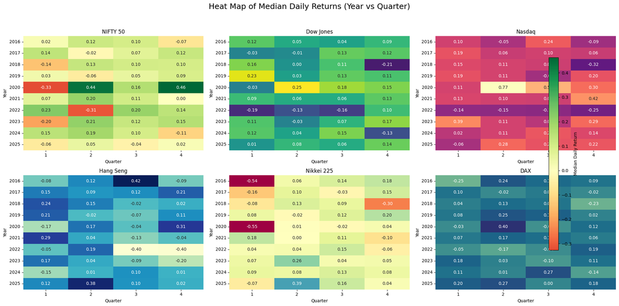

```python
# Create 2x3 subplot layout
fig, axes = plt.subplots(2, 3, figsize=(20, 10))
fig.suptitle("Heat Map of Median Daily Returns (Year vs Quarter)", fontsize=18)

markets = [
    ("Nifty50_Daily_Return", "NIFTY 50"),
    ("DowJones_Daily_Return", "Dow Jones"),
    ("NASDAQ_Daily_Return", "Nasdaq"),
    ("HangSeng_Daily_Return", "Hang Seng"),
    ("Nikkei225_Daily_Return", "Nikkei 225"),
    ("DAX_Daily_Return", "DAX")
]

# Different colormaps
cmaps = ["RdYlGn", "viridis", "magma", "YlGnBu", "Spectral", "crest"]

# Loop through markets
for ax, (col, title), cmap in zip(axes.flatten(), markets, cmaps):
    pivot_table = master_df.pivot_table(
        values=col,
        index="Year",
        columns="Quarter",
        aggfunc="median"
    )

    sns.heatmap(
        pivot_table,
        ax=ax,
        annot=True,
        fmt=".2f",
        cmap=cmap,   # different color for each
        center=0,
        cbar=False
    )

    ax.set_title(title)
    ax.set_xlabel("Quarter")
    ax.set_ylabel("Year")

# Add one common colorbar (based on first heatmap)
cbar = fig.colorbar(
    axes[0, 0].collections[0],
    ax=axes,
    orientation="vertical",
    fraction=0.02,
    pad=0.02
)
cbar.set_label("Median Daily Return")

plt.tight_layout(rect=[0, 0, 1, 0.95])
plt.show()
```

**Nifty50**

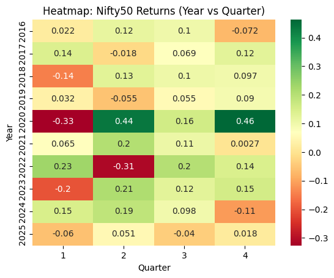

```python
pivot = df_5y.pivot_table(
    values='Nifty50_Daily_Return',
    index='Year',
    columns='Quarter',
    aggfunc='median'
)

sns.heatmap(pivot, annot=True, cmap='RdYlGn')
plt.title("Heatmap: Nifty50 Returns (Year vs Quarter)")
plt.show()
```

**Comment:** 2020 shows: Big loss in Q1 (-0.33) → market crash

Strong recovery in Q2 (0.44) and Q4 (0.46)

2023–2024: Mostly positive quarters → recovery period.

**DowJones**

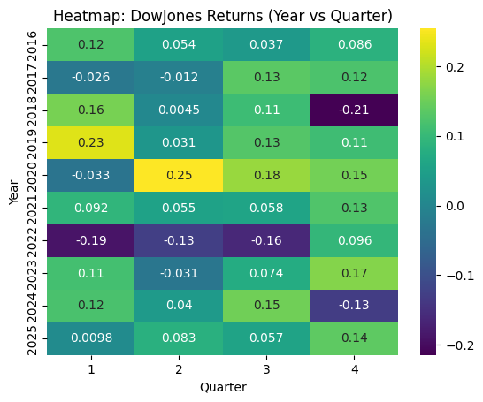

```python
pivot = df_5y.pivot_table(
    values='DowJones_Daily_Return',
    index='Year',
    columns='Quarter',
    aggfunc='median'
)

sns.heatmap(pivot, annot = True, cmap='viridis')
plt.title("Heatmap: DowJones Returns (Year vs Quarter)")
plt.show()
```

**Comment:** Q3 and Q4 generally show better performance than Q1 and Q2.

2020 shows a sharp drop in Q1 followed by a strong recovery in Q2–Q4.

**NASDAQ**

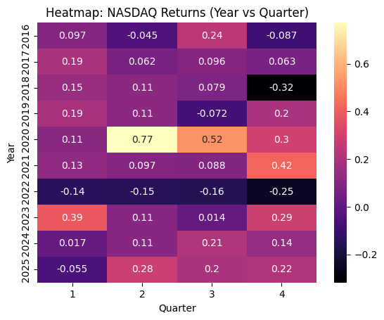

```python
pivot = df_5y.pivot_table(
    values='NASDAQ_Daily_Return',
    index='Year',
    columns='Quarter',
    aggfunc='median'
)

sns.heatmap(pivot, annot = True, cmap='magma')
plt.title("Heatmap: NASDAQ Returns (Year vs Quarter)")
plt.show()
```

**Comment:** 2022 is the worst year, with negative returns in all quarters.

2020 stands out with very high gains in Q2 (0.77)

**HangSeng**

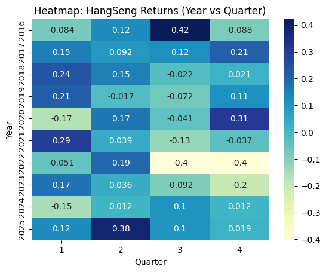

```python
pivot = df_5y.pivot_table(
    values='HangSeng_Daily_Return',
    index='Year',
    columns='Quarter',
    aggfunc='median'
)

sns.heatmap(pivot, annot = True, cmap='YlGnBu')
plt.title("Heatmap: HangSeng Returns (Year vs Quarter)")
plt.show()
```

**Comment:** Q2 generally performs better than other quarters, with consistent positive returns across many years.

• 2016 Q3 (0.42) and 2025 Q2 (0.38) show some of the highest gains in the dataset.

• 2022 is the worst-performing year, with sharp losses in Q3 and Q4 (–0.40 each).

**Nikkei225**

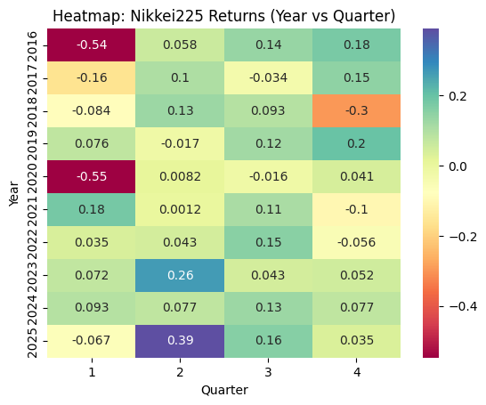

```python
pivot = df_5y.pivot_table(
    values='Nikkei225_Daily_Return',
    index='Year',
    columns='Quarter',
    aggfunc='median'
)

sns.heatmap(pivot, annot = True, cmap='Spectral')
plt.title("Heatmap: Nikkei225 Returns (Year vs Quarter)")
plt.show()
```

**Comment:** • Q2 is the strongest quarter with consistent gains.

• Big losses in Q1 during 2016 and 2020.

• 2025 Q2 (0.39) shows the highest return.

• 2018 Q4 shows a sharp decline.

• Overall, the market shows recovery and stability after 2020.

**DAX**

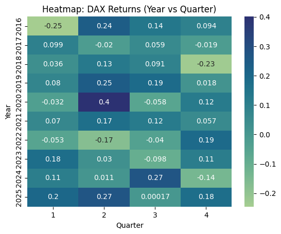

```python
pivot = df_5y.pivot_table(
    values='DAX_Daily_Return',
    index='Year',
    columns='Quarter',
    aggfunc='median'
)

sns.heatmap(pivot, annot = True, cmap='crest')
plt.title("Heatmap: DAX Returns (Year vs Quarter)")
plt.show()
```

**Comment:** • Q2 is the strongest quarter, with the highest gains (peak at 2020 Q2 = 0.40).

• 2020 shows strong recovery, especially in Q2 after early weakness.

• 2016 Q1 and 2018 Q4 show notable losses.

• 2022 has mixed/weak performance, with losses in Q1–Q3.

• 2024–2025 show mostly positive returns, indicating recovery.

# 2. Global Indices – Correlation Analysis

**2(a) Correlation Matrix of 10 years daily returns**

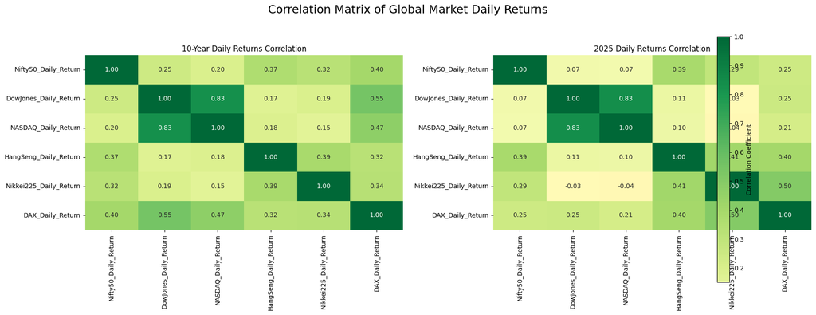

```python
# Calculate 10-Year Correlation Heatmap
returns_cols = [
    'Nifty50_Daily_Return',
    'DowJones_Daily_Return',
    'NASDAQ_Daily_Return',
    'HangSeng_Daily_Return',
    'Nikkei225_Daily_Return',
    'DAX_Daily_Return'
]

corr_10y = master_df[returns_cols].corr()

# Calculate 2025 Correlation Heatmap
corr_2025 = master_df[master_df['Year'] == 2025][returns_cols].corr()

# -------- Plotting --------
fig, axes = plt.subplots(1, 2, figsize=(18, 7))
fig.suptitle("Correlation Matrix of Global Market Daily Returns", fontsize=18)

# 10-Year Correlation Heatmap
sns.heatmap(
    corr_10y,
    annot=True,
    cmap="RdYlGn",   # changed colormap
    center=0,
    fmt=".2f",
    ax=axes[0],
    cbar=False
)
axes[0].set_title("10-Year Daily Returns Correlation")

# 2025 Correlation Heatmap
sns.heatmap(
    corr_2025,
    annot=True,
    cmap="RdYlGn",   # changed colormap
    center=0,
    fmt=".2f",
    ax=axes[1],
    cbar=False
)
axes[1].set_title("2025 Daily Returns Correlation")

# One common colorbar
cbar = fig.colorbar(
    axes[0].collections[0],
    ax=axes,
    orientation="vertical",
    fraction=0.03,
    pad=0.02
)
cbar.set_label("Correlation Coefficient")

plt.tight_layout(rect=[0, 0, 1, 0.93])
plt.show()
```

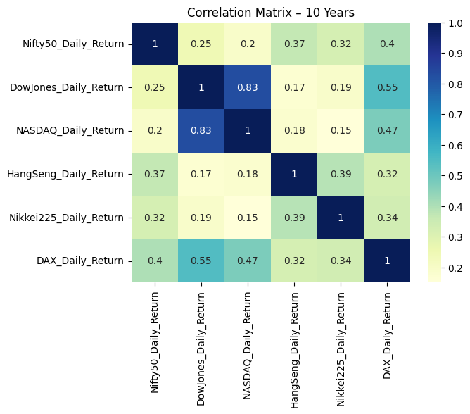

```python
returns_cols = [
    'Nifty50_Daily_Return',
    'DowJones_Daily_Return',
    'NASDAQ_Daily_Return',
    'HangSeng_Daily_Return',
    'Nikkei225_Daily_Return',
    'DAX_Daily_Return'
]

sns.heatmap(master_df[returns_cols].corr(), annot=True, cmap='YlGnBu')
plt.title("Correlation Matrix – 10 Years")
plt.show()
```

**Comment:** • Dow Jones and NASDAQ have the strongest correlation (0.83), meaning they move very closely.

• DAX shows moderate correlation with Dow Jones and NASDAQ.

• NIFTY 50 has a moderate relationship with other global markets.

• Hang Seng and Nikkei 225 show lower correlation with the other indices.

• Overall, correlations are positive but not perfect, allowing diversification.

**2(b) Correlation Matrix of 2025 daily returns**

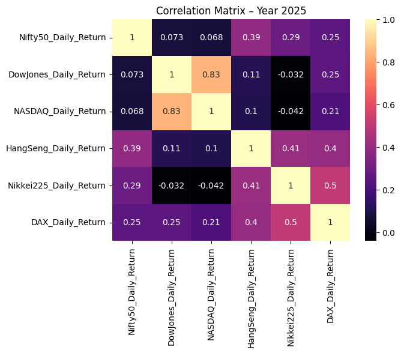

```python
sns.heatmap(
    master_df[master_df['Year'] == 2025][returns_cols].corr(),
    annot=True,
    cmap='magma'
)
plt.title("Correlation Matrix – Year 2025")
plt.show()
```

# 3. Pre-Post Covid Performance Analytics-time required for a market to come back To pre-covid level

```python
def covid_recovery_time(df, price_col):
    pre = df[df['Date'] < '2020-02-01']
    peak_price = pre[price_col].max()
    peak_date = pre.loc[pre[price_col].idxmax(), 'Date']

    post = df[df['Date'] >= '2020-02-01']
    recovery_date = post[post[price_col] >= peak_price]['Date'].min()

    days = (recovery_date - peak_date).days
    return days
```

```python
covid_recovery_time(master_df, 'Nifty50_Close')
```

```
300
```

```python
covid_recovery_time(master_df, 'NASDAQ_Close')
```

```
12
```

```python
covid_recovery_time(master_df, 'Nikkei225_Close')
```

```
766
```

```python
covid_recovery_time(master_df, 'DAX_Close')
```

```
18
```

```python
covid_recovery_time(master_df, 'HangSeng_Close')
```

```
nan
```

# 4. NIFTY 50 DAILY MOVEMENT – PRE-MODELING WORK

**a) Define Nifty_Open_Dir**

**1 → Nifty opens higher than yesterday’s close (positive opening)**

**0 → Otherwise**

```python
# If today's Nifty Open > yesterday's Close → 1 else 0
master_df['Nifty_Open_Dir'] = (
    master_df['Nifty50_Open'] > master_df['Nifty50_Close'].shift(1)
).astype(int)
```

```python
master_df[["Date", "Nifty50_Open", "Nifty50_Close", "Nifty_Open_Dir"]].head()
```

|  | Date | Nifty50_Open | Nifty50_Close | Nifty_Open_Dir |
| --- | --- | --- | --- | --- |
| 0 | 2016-01-04 | 7924.549805 | 7791.299805 | 0 |
| 1 | 2016-01-05 | 7828.399902 | 7784.649902 | 1 |
| 2 | 2016-01-06 | 7788.049805 | 7741.000000 | 1 |
| 3 | 2016-01-07 | 7673.350098 | 7568.299805 | 0 |
| 4 | 2016-01-08 | 7611.649902 | 7601.350098 | 1 |

**Insight:** Today’s Opening price is compared with yesterday’s Closing price. The target variable converts the problem into a binary classification task, representing whether the market opens positive or negative.

**b) Table of % of Nifty_Open_Dir=1 by year**

**Meaning : Shows how often Nifty opens positive each year.**

```python
# Percentage of positive openings per year
open_dir_pct = master_df.groupby('Year')['Nifty_Open_Dir'].mean() * 100

open_dir_pct
```

| Year | Nifty_Open_Dir |
| --- | --- |
| 2016 | 66.923077 |
| 2017 | 74.615385 |
| 2018 | 70.384615 |
| 2019 | 69.230769 |
| 2020 | 70.610687 |
| 2021 | 71.647510 |
| 2022 | 59.230769 |
| 2023 | 67.307692 |
| 2024 | 64.503817 |
| 2025 | 59.003831 |

**dtype:** float64

**Comment:**

74.6% in 2017 → Very strong year with frequent positive openings.

2022 (~59.2%) → Fewer positive openings → weaker or uncertain market.

**c) % of NEGATIVE openings per year**

```python
neg_open_dir_pct = 100 - open_dir_pct
neg_open_dir_pct
```

| Year | Nifty_Open_Dir |
| --- | --- |
| 2016 | 33.076923 |
| 2017 | 25.384615 |
| 2018 | 29.615385 |
| 2019 | 30.769231 |
| 2020 | 29.389313 |
| 2021 | 28.352490 |
| 2022 | 40.769231 |
| 2023 | 32.692308 |
| 2024 | 35.496183 |
| 2025 | 40.996169 |

**dtype:** float64

**Comment:** Negative Nifty openings were lowest in 2017, indicating strong bullish sentiment, while 2022 and 2025 show the highest negative opening percentages, reflecting increased market uncertainty and volatility.

**d) Visualize/summarize global indices including VIX for 2 categories of Nifty_Open_Dir**

This checks:

“When Nifty opens positive vs negative, how do global markets behave?”

This helps in feature selection for modeling.

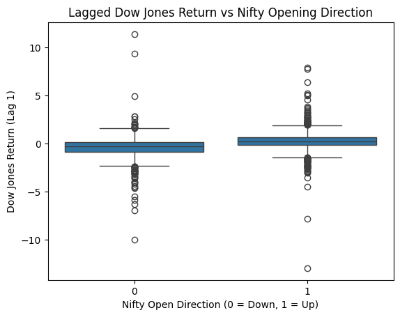

```python
# Lagged Dow Jones return (yesterday's return)
master_df['DJI_Return_Lag1'] = master_df['DowJones_Daily_Return'].shift(1)

# Box plot: Dow Jones lagged return vs Nifty opening direction
sns.boxplot(
    x='Nifty_Open_Dir',
    y='DJI_Return_Lag1',
    data=master_df
)

plt.title("Lagged Dow Jones Return vs Nifty Opening Direction")
plt.xlabel("Nifty Open Direction (0 = Down, 1 = Up)")
plt.ylabel("Dow Jones Return (Lag 1)")
plt.show()
```

**Comment:** • The chart compares yesterday’s Dow Jones return with today’s Nifty opening direction.

• When the Dow Jones return is positive, Nifty is more likely to open up.

• When the Dow Jones return is negative, Nifty is more likely to open down.

# Percentage of Positive Opening Direction by Year

```python
markets = [
    'DowJones',
    'NASDAQ',
    'HangSeng',
    'Nikkei225',
    'DAX'
]

for market in markets:
    master_df[f'{market}_Open_Dir'] = (
        master_df[f'{market}_Open'] > master_df[f'{market}_Close'].shift(1)
    ).astype(int)
```

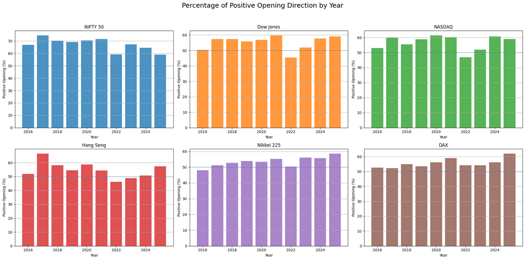

```python
# Create 2x3 subplot layout
fig, axes = plt.subplots(2, 3, figsize=(20, 10))
fig.suptitle("Percentage of Positive Opening Direction by Year", fontsize=18)

markets = [
    ("Nifty_Open_Dir", "NIFTY 50", "#1f77b4"),
    ("DowJones_Open_Dir", "Dow Jones", "#ff7f0e"),
    ("NASDAQ_Open_Dir", "NASDAQ", "#2ca02c"),
    ("HangSeng_Open_Dir", "Hang Seng", "#d62728"),
    ("Nikkei225_Open_Dir", "Nikkei 225", "#9467bd"),
    ("DAX_Open_Dir", "DAX", "#8c564b")
]

# Loop through markets
for ax, (col, title, color) in zip(axes.flatten(), markets):
    open_dir_pct = master_df.groupby("Year")[col].mean() * 100

    ax.bar(
        open_dir_pct.index,
        open_dir_pct.values,
        color=color,
        alpha=0.8
    )

    ax.set_title(title)
    ax.set_xlabel("Year")
    ax.set_ylabel("Positive Opening (%)")
    ax.axhline(50, linestyle="--", linewidth=0.8)  # neutrality line
    ax.grid(True, axis='y')  # grid only on y-axis for bar chart

plt.tight_layout(rect=[0, 0, 1, 0.95])
plt.show()
```

```python
from google.colab import files
f = files.upload()

# Convert ipynb to html
import subprocess
file0 = list(f.keys())[0]
_ = subprocess.run(["pip", "install", "nbconvert"])
_ = subprocess.run(["jupyter", "nbconvert", file0, "--to", "html"])

# download the html
files.download(file0[:-5]+"html")
```

Upload widget is only available when the cell has been executed in the current browser session. Please rerun this cell to enable.